# Intensifiers

erin

```r
### load required packages

library(lme4, quietly=T)
library(ggplot2, quietly=T)
library(plyr, quietly=T)
library(rjson, quietly=T)
source("~/opt/r_helper_scripts/bootsSummary.r")
gg_color_hue <- function(n) {
  hues = seq(15, 375, length=n+1)
  hcl(h=hues, l=65, c=100)[1:n]
}
```

# Experiment 1

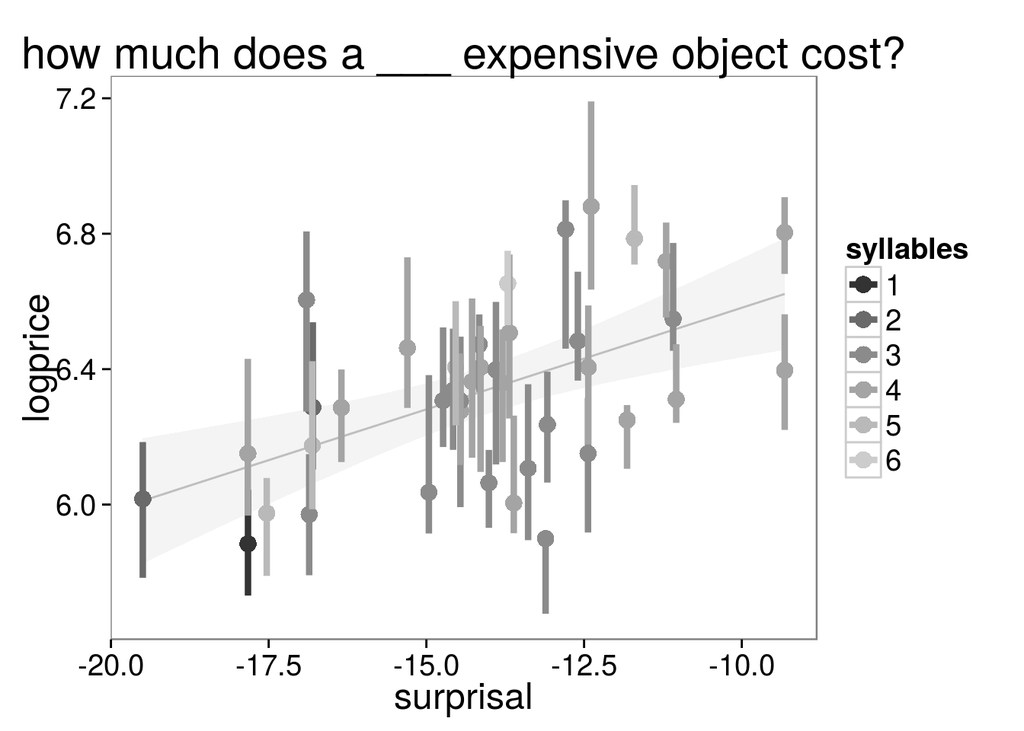

```r
### load experiment data

d = read.table("degree-adverbs-exp5.tsv", header=T, sep="\t")
d$intensifier = as.character(d$adverb)
d = d[,c("workerid", "intensifier", "object", "response", "gender")]
d$workerid = as.factor(d$workerid)
d$logprice = log(d$response)

### load web ngrams data
web_1grams = read.table("web_1grams.csv", header=T, sep=",")
syllables = web_1grams$syllables
names(syllables) = web_1grams$ngram
ngrams = read.table("web_1grams.csv", header=T, sep=",")
frequencies = ngrams$frequency
names(frequencies) = as.character(ngrams$ngram)
d$frequency = sapply(d$intensifier, function(adverb) {return(frequencies[adverb])})
d$syllables = sapply(d$intensifier, function(adverb) {return(syllables[adverb])})
# total_tokens = 1024908267229
# total_1grams = total_tokens
# total_unique_2grams = 314843401
# total_2grams = total_tokens - 40 + total_unique_2grams #because i +40 smoothed the 2grams
# total_ngrams = total_1grams
#d$surprisal = log(total_ngrams) - log(d$frequency)
d$surprisal = - log(d$frequency)
d = d[d$surprisal != 0,]
d$c.surprisal = d$surprisal - mean(d$surprisal)
d$c.syllables = d$syllables - mean(d$syllables)

d_summary = bootsSummary(data=d, measurevar="logprice", groupvars=c("intensifier", "surprisal", "syllables"))
d_summary$syllables = as.ordered(d_summary$syllables)
p = ggplot(data=d_summary, aes(x=surprisal, y=logprice, colour=syllables)) +
  geom_smooth(method="lm", colour="grey", alpha=1/10) +
  geom_point(size=4) +
  theme_bw(18) +
  scale_colour_grey() +
  theme(panel.grid=element_blank()) +
  ggtitle("how much does a ___ expensive object cost?") +
  geom_errorbar(aes(ymin=bootsci_low, ymax=bootsci_high, x=surprisal, width=0), lwd=1.5)
print(p)
```

```r
ggsave("images/exp1-plot.png", width=10, height=6)
```

We used 40 intensifiers. There were 30 participants.

```r
print(ngrams)
```

```
##              ngram frequency syllables
## 1     surpassingly     11156         4
## 2       colossally     11167         4
## 3     terrifically     62292         4
## 4      frightfully     65389         3
## 5     astoundingly     73041         4
## 6     phenomenally    120769         5
## 7       uncommonly    135747         4
## 8     outrageously    240010         4
## 9    fantastically    250989         4
## 10        mightily    252135         3
## 11       supremely    296134         3
## 12        insanely    359644         3
## 13      strikingly    480417         3
## 14         acutely    493931         3
```

[output cut: 26 more lines]

The correlation between surprisal and syllable length in our data was only 0.2648.

We found significant positive main effects of surprisal and syllable length and a significant positive interaction.

```r
library(lmerTest, quietly=T)
d$c.surprisal = d$surprisal - mean(d$surprisal)
d$c.syllables = d$syllables - mean(d$syllables)
full_model = lmer(logprice ~ c.surprisal * c.syllables +
                        (1 + c.surprisal + c.syllables | workerid) +
                        (1 + c.surprisal + c.syllables | object), data=d)
print(summary(full_model))
```

```
## Linear mixed model fit by REML ['merModLmerTest']
## Formula:
## logprice ~ c.surprisal * c.syllables + (1 + c.surprisal + c.syllables |
##     workerid) + (1 + c.surprisal + c.syllables | object)
##    Data: d
##
## REML criterion at convergence: 7441
##
## Scaled residuals:
##    Min     1Q Median     3Q    Max
## -3.713 -0.624 -0.036  0.553  3.992
##
## Random effects:
##  Groups   Name        Variance Std.Dev. Corr
##  workerid (Intercept) 0.325783 0.5708
##           c.surprisal 0.000369 0.0192   0.37
##           c.syllables 0.000499 0.0223   0.27  0.99
##  object   (Intercept) 0.796977 0.8927
##           c.surprisal 0.000149 0.0122    0.06
##           c.syllables 0.000319 0.0178   -0.42  0.88
##  Residual             0.438664 0.6623
## Number of obs: 3600, groups:  workerid, 30; object, 3
##
## Fixed effects:
##                         Estimate Std. Error       df t value Pr(>|t|)
## (Intercept)             6.33e+00   5.26e-01 2.00e+00   12.03  0.00505 **
## c.surprisal             5.37e-02   9.35e-03 3.00e+00    5.74  0.01187 *
## c.syllables             9.31e-02   1.82e-02 5.00e+00    5.11  0.00413 **
## c.surprisal:c.syllables 1.93e-02   5.15e-03 3.53e+03    3.75  0.00018 ***
## ---
## Signif. codes:  0 '***' 0.001 '**' 0.01 '*' 0.05 '.' 0.1 ' ' 1
##
## Correlation of Fixed Effects:
##             (Intr) c.srpr c.syll
## c.surprisal  0.069
## c.syllables -0.224  0.369
## c.srprsl:c. -0.005  0.019  0.402
```

I decided to include an interaction term in the regreesion because an anova showed that to be a better fit,

```r
no_interaction_model = lmer(logprice ~ c.surprisal + c.syllables +
                        (1 + c.surprisal + c.syllables | workerid) +
                        (1 + c.surprisal + c.syllables | object), data=d)
print(anova(no_interaction_model, full_model))
```

```
## Data: d
## Models:
## object: logprice ~ c.surprisal + c.syllables + (1 + c.surprisal + c.syllables |
## object:     workerid) + (1 + c.surprisal + c.syllables | object)
## ..1: logprice ~ c.surprisal * c.syllables + (1 + c.surprisal + c.syllables |
## ..1:     workerid) + (1 + c.surprisal + c.syllables | object)
##        Df  AIC  BIC logLik deviance Chisq Chi Df Pr(>Chisq)
## object 16 7465 7564  -3716     7433
## ..1    17 7453 7558  -3709     7419    14      1    0.00018 ***
## ---
## Signif. codes:  0 '***' 0.001 '**' 0.01 '*' 0.05 '.' 0.1 ' ' 1
```

and because the graph looks like it might have an interaction.

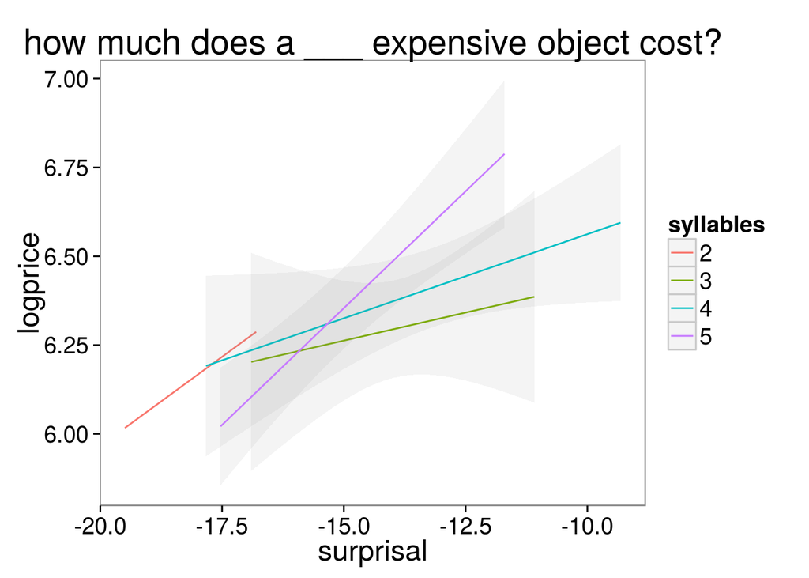

```r
d_summary = bootsSummary(data=d, measurevar="logprice", groupvars=c("intensifier", "surprisal", "syllables"))
d_summary$syllables = as.ordered(d_summary$syllables)
p = ggplot(data=d_summary, aes(x=surprisal, y=logprice, colour=syllables)) +
  geom_smooth(method="lm", alpha=1/10) +
  #geom_point(size=4) +
  theme_bw(18) +
  #scale_colour_grey() +
  theme(panel.grid=element_blank()) +
  ggtitle("how much does a ___ expensive object cost?") #+
  #geom_errorbar(aes(ymin=bootsci_low, ymax=bootsci_high, x=surprisal, width=0), lwd=1.5)
print(p)
```

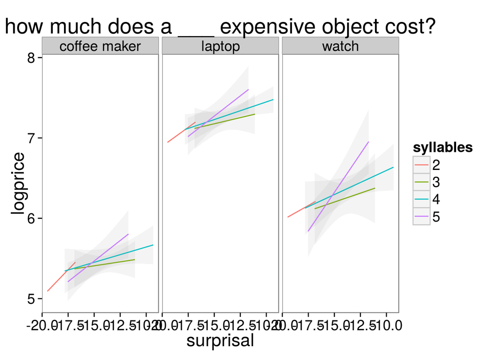

```r
d_summary = bootsSummary(data=d, measurevar="logprice", groupvars=c("intensifier", "surprisal", "syllables", "object"))
d_summary$syllables = as.ordered(d_summary$syllables)
p = ggplot(data=d_summary, aes(x=surprisal, y=logprice, colour=syllables)) +
  geom_smooth(method="lm", alpha=1/10) +
  #geom_point(size=4) +
  theme_bw(18) +
  facet_wrap(~ object) +
  #scale_colour_grey() +
  theme(panel.grid=element_blank()) +
  ggtitle("how much does a ___ expensive object cost?") #+
  #geom_errorbar(aes(ymin=bootsci_low, ymax=bootsci_high, x=surprisal, width=0), lwd=1.5)
print(p)
```

There is no random slope for the interaction for worker or object, because when there was, the model wouldn’t converge. There are other ways I could have simplified the structure of the mixed effects model, but this seemed reasonable. The difference between the mixed effects model and the simple model with just fixed effects is actually not that big, anyway.

```r
fit = lm(logprice ~ c.surprisal * c.syllables, data=d)
print(summary(fit))
```

```
##
## Call:
## lm(formula = logprice ~ c.surprisal * c.syllables, data = d)
##
## Residuals:
##    Min     1Q Median     3Q    Max
## -3.175 -0.958 -0.073  0.881  3.660
##
## Coefficients:
##                         Estimate Std. Error t value Pr(>|t|)
## (Intercept)              6.32685    0.01954  323.73  < 2e-16 ***
## c.surprisal              0.05365    0.00865    6.20  6.2e-10 ***
## c.syllables              0.09311    0.02478    3.76  0.00017 ***
## c.surprisal:c.syllables  0.01931    0.00883    2.19  0.02877 *
## ---
## Signif. codes:  0 '***' 0.001 '**' 0.01 '*' 0.05 '.' 0.1 ' ' 1
##
## Residual standard error: 1.14 on 3596 degrees of freedom
## Multiple R-squared:  0.018,  Adjusted R-squared:  0.0172
## F-statistic:   22 on 3 and 3596 DF,  p-value: 3.95e-14
```

It also doesn’t seem to make much of a difference if I have the random slope be on the interaction rather than on the individual predictors.

```r
full_model = lmer(logprice ~ c.surprisal * c.syllables +
                        (1 + c.surprisal:c.syllables | workerid) +
                        (1 + c.surprisal:c.syllables | object), data=d)
print(summary(full_model))
```

```
## Linear mixed model fit by REML ['merModLmerTest']
## Formula:
## logprice ~ c.surprisal * c.syllables + (1 + c.surprisal:c.syllables |
##     workerid) + (1 + c.surprisal:c.syllables | object)
##    Data: d
##
## REML criterion at convergence: 7452
##
## Scaled residuals:
##    Min     1Q Median     3Q    Max
## -3.740 -0.614 -0.040  0.555  3.944
##
## Random effects:
##  Groups   Name                    Variance Std.Dev. Corr
##  workerid (Intercept)             3.25e-01 0.56984
##           c.surprisal:c.syllables 2.70e-06 0.00164  1.00
##  object   (Intercept)             7.95e-01 0.89180
##           c.surprisal:c.syllables 3.55e-06 0.00188  1.00
##  Residual                         4.42e-01 0.66498
## Number of obs: 3600, groups:  workerid, 30; object, 3
##
## Fixed effects:
##                         Estimate Std. Error       df t value Pr(>|t|)
## (Intercept)             6.33e+00   5.25e-01 2.00e+00   12.04  0.00505 **
## c.surprisal             5.37e-02   5.07e-03 3.56e+03   10.59  < 2e-16 ***
## c.syllables             9.31e-02   1.45e-02 3.56e+03    6.42  1.6e-10 ***
## c.surprisal:c.syllables 1.93e-02   5.29e-03 3.20e+01    3.65  0.00094 ***
## ---
## Signif. codes:  0 '***' 0.001 '**' 0.01 '*' 0.05 '.' 0.1 ' ' 1
##
## Correlation of Fixed Effects:
##             (Intr) c.srpr c.syll
## c.surprisal  0.000
## c.syllables -0.003 -0.210
## c.srprsl:c.  0.207  0.034  0.495
```

# Experiment 2

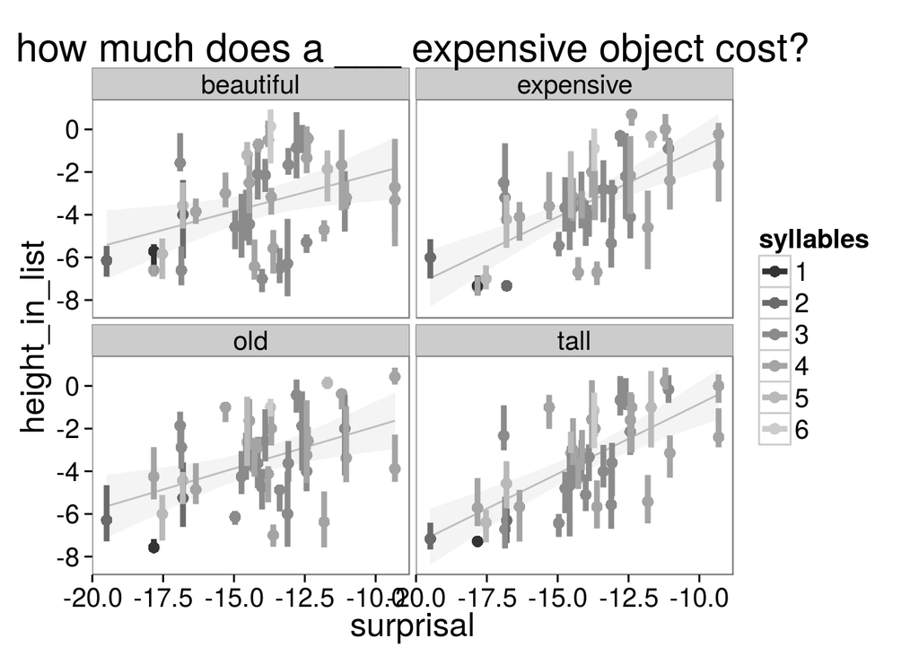

```r
### define different adjective sets
list_a = c(
  "surpassingly",
  "astoundingly",
  "fantastically",
  "strikingly",
  "excessively",
  "markedly",
  "remarkably",
  "utterly",
  "truly",
  "particularly"
)
list_b = c(
  "colossally",
  "phenomenally",
  "mightily",
  "acutely",
  "extraordinarily",
  "amazingly",
  "terribly",
  "notably",
  "significantly",
  "quite"
)
list_c = c(
  "terrifically",
  "uncommonly",
  "supremely",
  "awfully",
  "exceedingly",
  "radically",
  "exceptionally",
  "incredibly",
  "totally",
  "especially"
)
list_d = c(
  "frightfully",
  "outrageously",
  "insanely",
  "decidedly",
  "intensely",
  "unusually",
  "desperately",
  "seriously",
  "extremely",
  "very"
)
### load data
d = read.table("degree-adverbs-exp4.tsv", header=T, sep="\t")
d = d[,c("workerid", "trial", "adverb", "ranking", "asses")]
d$adjective_phrase = d$adverb
d$adverb = sapply(strsplit(as.character(d$adjective_phrase), " "), function(lst) {return(lst[[1]])})
d$adjective = sapply(strsplit(as.character(d$adjective_phrase), " "), function(lst) {return(lst[[2]])})
d$adverb_list = rep("A", nrow(d))
d$adverb_list[d$adverb %in% list_b] = "B"
d$adverb_list[d$adverb %in% list_c] = "C"
d$adverb_list[d$adverb %in% list_d] = "D"
frequencies = ngrams$frequency
names(frequencies) = ngrams$ngram
d$frequency = sapply(d$adverb, function(adverb) {return(frequencies[adverb])})
d$syllables = sapply(d$adverb, function(adverb) {return(syllables[adverb])})
#d$surprisal = log(total_ngrams)-log(d$frequency)
d$surprisal = -log(d$frequency)
d = ddply(d, .(workerid, adverb_list), transform, rank_order = rank(frequency))
d$height_in_list = 1-d$ranking

d_summary = bootsSummary(data=d, measurevar="height_in_list", groupvars=c("surprisal", "adjective", "adverb", "adverb_list", "syllables"))
d_summary$syllables = as.factor(d_summary$syllables)
p = ggplot(data=d_summary, aes(x=surprisal, y=height_in_list, colour=syllables)) +
  geom_smooth(method="lm", colour="grey", alpha=1/10) +
  geom_point(size=3) +
  theme_bw(18) +
  scale_colour_grey() +
  facet_wrap(~ adjective) +
  theme(panel.grid=element_blank()) +
  ggtitle("how much does a ___ expensive object cost?") +
  geom_errorbar(aes(ymin=bootsci_low, ymax=bootsci_high, x=surprisal, width=0), lwd=1.5)
print(p)
```

```r
ggsave("images/exp2-plot.png", width=10, height=6)
```

The same 40 intensifiers were used. There were 30 participants.

There were main effects of surprisal and syllable length, and a signficant interaction.

```r
d$c.surprisal = d$surprisal - mean(d$surprisal)
d$c.syllables = d$syllables - mean(d$syllables)
full_model = lm(height_in_list ~ c.surprisal * c.syllables, data=d)
print(summary(full_model))
```

```
##
## Call:
## lm(formula = height_in_list ~ c.surprisal * c.syllables, data = d)
##
## Residuals:
##    Min     1Q Median     3Q    Max
## -7.035 -1.853  0.084  1.966  6.496
##
## Coefficients:
##                         Estimate Std. Error t value Pr(>|t|)
## (Intercept)              -3.5384     0.0770  -45.95  < 2e-16 ***
## c.surprisal               0.4559     0.0341   13.38  < 2e-16 ***
## c.syllables               0.6400     0.0976    6.56  8.2e-11 ***
## c.surprisal:c.syllables   0.0694     0.0348    2.00    0.046 *
## ---
## Signif. codes:  0 '***' 0.001 '**' 0.01 '*' 0.05 '.' 0.1 ' ' 1
##
## Residual standard error: 2.58 on 1196 degrees of freedom
## Multiple R-squared:  0.194,  Adjusted R-squared:  0.192
## F-statistic:   96 on 3 and 1196 DF,  p-value: <2e-16
```

The full model (with an interaction term) is again a better fit than the model without an interaction term.

```r
no_interaction_model = lm(height_in_list ~ c.surprisal + c.syllables, data=d)
print(anova(no_interaction_model, full_model))
```

```
## Analysis of Variance Table
##
## Model 1: height_in_list ~ c.surprisal + c.syllables
## Model 2: height_in_list ~ c.surprisal * c.syllables
##   Res.Df  RSS Df Sum of Sq    F Pr(>F)
## 1   1197 8006
## 2   1196 7979  1      26.6 3.98  0.046 *
## ---
## Signif. codes:  0 '***' 0.001 '**' 0.01 '*' 0.05 '.' 0.1 ' ' 1
```

The graph again looks like there might be a multiplicative effect.

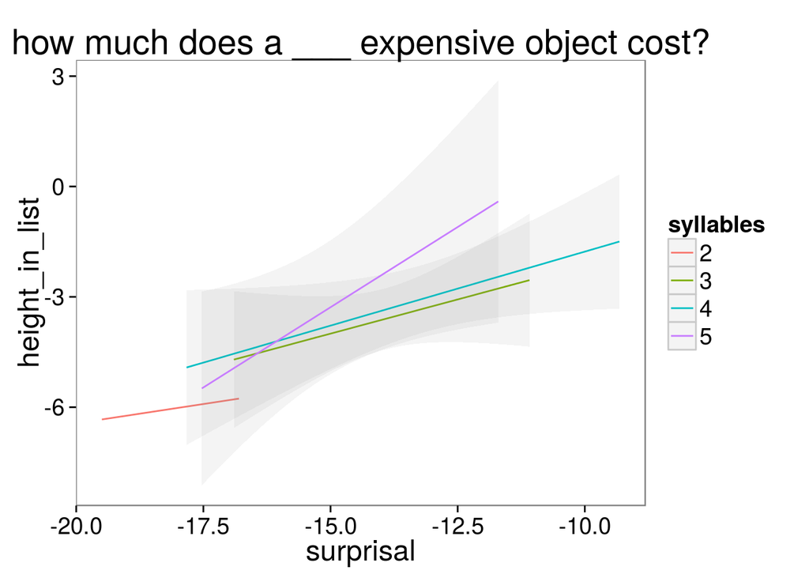

```r
d_summary = bootsSummary(data=d, measurevar="height_in_list", groupvars=c("surprisal", "syllables"))
d_summary$syllables = as.factor(d_summary$syllables)
p = ggplot(data=d_summary, aes(x=surprisal, y=height_in_list, colour=syllables)) +
  geom_smooth(method="lm", alpha=1/10) +
  #geom_point(size=4) +
  theme_bw(18) +
  theme(panel.grid=element_blank()) +
  ggtitle("how much does a ___ expensive object cost?") #+
  #geom_errorbar(aes(ymin=bootsci_low, ymax=bootsci_high, x=surprisal, width=0), lwd=1.5)
print(p)
```

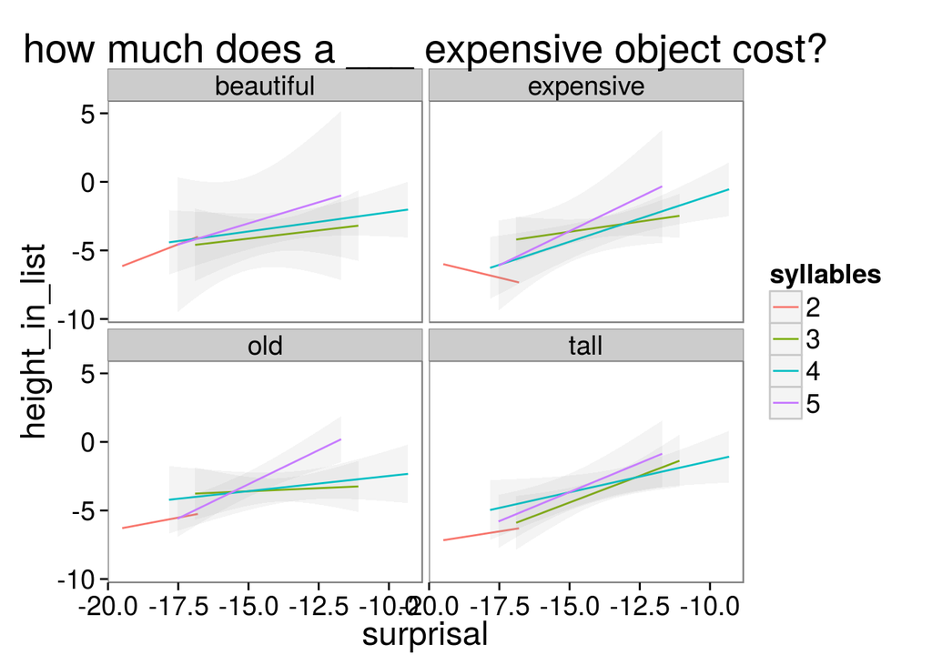

```r
d_summary = bootsSummary(data=d, measurevar="height_in_list", groupvars=c("surprisal", "syllables", "adjective"))
d_summary$syllables = as.factor(d_summary$syllables)
p = ggplot(data=d_summary, aes(x=surprisal, y=height_in_list, colour=syllables)) +
  geom_smooth(method="lm", alpha=1/10) +
  #geom_point(size=4) +
  theme_bw(18) +
  facet_wrap(~ adjective) +
  theme(panel.grid=element_blank()) +
  ggtitle("how much does a ___ expensive object cost?") #+
  #geom_errorbar(aes(ymin=bootsci_low, ymax=bootsci_high, x=surprisal, width=0), lwd=1.5)
print(p)
```

# Experiment 3

There were 18 participants.

Frequency estimates for an adverb were significantly higher when that adverb was the target (repeated) adverb.

```r
fit = lmer(response ~ word_type + (1 | word) + (1 | workerid), data=d[d$qtype == "frequency" & d$word_type != "yep",])
print(summary(fit))
```

```
## Linear mixed model fit by REML ['merModLmerTest']
## Formula: response ~ word_type + (1 | word) + (1 | workerid)
##    Data: d[d$qtype == "frequency" & d$word_type != "yep", ]
##
## REML criterion at convergence: 378.4
##
## Scaled residuals:
##    Min     1Q Median     3Q    Max
## -1.303 -0.372 -0.128  0.267  3.384
##
## Random effects:
##  Groups   Name        Variance Std.Dev.
##  workerid (Intercept) 1600     40.0
##  word     (Intercept)    0      0.0
##  Residual             2123     46.1
## Number of obs: 36, groups:  workerid, 18; word, 2
##
## Fixed effects:
##                 Estimate Std. Error   df t value Pr(>|t|)
## (Intercept)         37.8       14.4 28.7    2.63    0.014 *
## word_typetarget     34.1       15.4 17.0    2.22    0.041 *
## ---
## Signif. codes:  0 '***' 0.001 '**' 0.01 '*' 0.05 '.' 0.1 ' ' 1
##
## Correlation of Fixed Effects:
##             (Intr)
## wrd_typtrgt -0.534
```

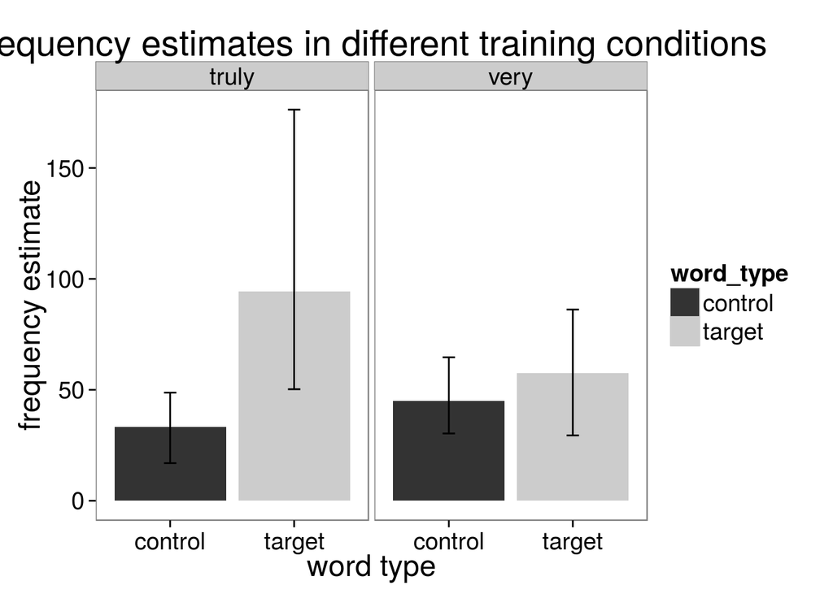

```r
d_freq_summary = bootsSummary(d[d$qtype == "frequency" & d$word_type != "yep",], measurevar="response",
                         groupvars=c("word_type", "word"))
dodge = position_dodge(width=0.9)
p = ggplot(data=d_freq_summary, aes(x=word_type, y=response, fill=word_type)) +
  geom_bar(stat="identity", position=dodge) +
  geom_errorbar(aes(ymin=bootsci_low, ymax=bootsci_high, x=word_type),
                position=dodge, width=0.1) +
  theme_bw(18) +
  facet_wrap(~ word) +
  xlab("word type") +
  ylab("frequency estimate") +
  theme(panel.grid=element_blank()) +
  scale_fill_grey() +
  ggtitle("frequency estimates in different training conditions")
print(p)
```

```r
ggsave("images/exp3-freq-plot.png", width=10, height=6)
```

Price estimates were significantly lower when the adverb was the target adverb.

```r
fit = lmer(diff ~ word_type + (1 | word) + (1 | workerid), data=d_price_diff)
print(summary(fit))
```

```
## Linear mixed model fit by REML ['merModLmerTest']
## Formula: diff ~ word_type + (1 | word) + (1 | workerid)
##    Data: d_price_diff
##
## REML criterion at convergence: 363.1
##
## Scaled residuals:
##    Min     1Q Median     3Q    Max
## -1.013 -0.439 -0.151  0.142  3.475
##
## Random effects:
##  Groups   Name        Variance Std.Dev.
##  workerid (Intercept)  924     30.4
##  word     (Intercept)    0      0.0
##  Residual             1411     37.6
## Number of obs: 36, groups:  workerid, 18; word, 2
##
## Fixed effects:
##                 Estimate Std. Error    df t value Pr(>|t|)
## (Intercept)         58.9       11.4  29.4    5.17  1.5e-05 ***
## word_typetarget    -31.4       12.5  17.0   -2.51    0.023 *
## ---
## Signif. codes:  0 '***' 0.001 '**' 0.01 '*' 0.05 '.' 0.1 ' ' 1
##
## Correlation of Fixed Effects:
##             (Intr)
## wrd_typtrgt -0.550
```

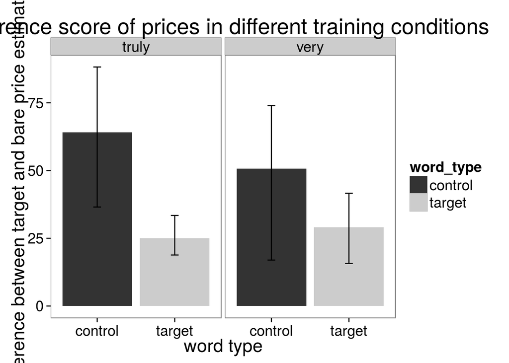

```r
dodge = position_dodge(width=0.9)
p = ggplot(data=d_diff_summary_type, aes(x=word_type, y=diff, fill=word_type)) +
  geom_bar(stat="identity", position=dodge) +
  geom_errorbar(aes(ymin=bootsci_low, ymax=bootsci_high, x=word_type),
                position=dodge, width=0.1) +
  theme_bw(18) +
  facet_wrap(~ word) +
  xlab("word type") +
  ylab("difference between target and bare price estimates") +
  theme(panel.grid=element_blank()) +
  scale_fill_grey() +
  ggtitle("difference score of prices in different training conditions")
print(p)
```

```r
ggsave("images/exp3-price-plot.png", width=10, height=6)
```

Price estimates correlated with frequency estimates.

```r
fit = lm(response.price ~ response.frequency, data=d_freq_vs_price)
print(summary(fit))
```

```
##
## Call:
## lm(formula = response.price ~ response.frequency, data = d_freq_vs_price)
##
## Residuals:
##    Min     1Q Median     3Q    Max
##  -65.2  -48.2  -14.4   27.2  198.0
##
## Coefficients:
##                    Estimate Std. Error t value Pr(>|t|)
## (Intercept)         102.456     13.311    7.70    6e-09 ***
## response.frequency   -0.225      0.161   -1.39     0.17
## ---
## Signif. codes:  0 '***' 0.001 '**' 0.01 '*' 0.05 '.' 0.1 ' ' 1
##
## Residual standard error: 59.7 on 34 degrees of freedom
## Multiple R-squared:  0.054,  Adjusted R-squared:  0.0262
## F-statistic: 1.94 on 1 and 34 DF,  p-value: 0.173
```

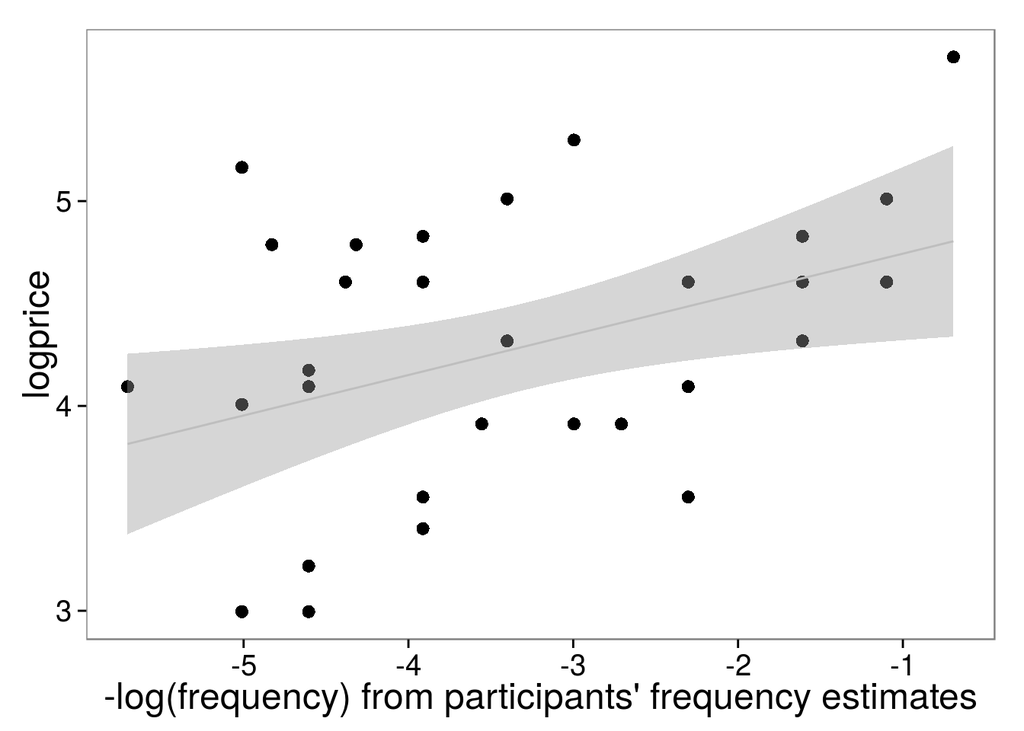

```r
p = ggplot(data=d_freq_vs_price, aes(x=-log(response.frequency), y=log(response.price))) +
  geom_point(size=3) +
  theme_bw(18) +
  xlab("-log(frequency) from participants' frequency estimates") +
  ylab("logprice") +
  theme(panel.grid=element_blank()) +
  geom_smooth(method="lm", colour="grey")
print(p)
```

```r
ggsave("images/exp3-scatterplot.png", width=10, height=6)

with(d_freq_vs_price, cor.test(-log(response.frequency), log(response.price)), method="pearson")
```

```
##
##  Pearson's product-moment correlation
##
## data:  -log(response.frequency) and log(response.price)
## t = 2.513, df = 34, p-value = 0.01688
## alternative hypothesis: true correlation is not equal to 0
## 95 percent confidence interval:
##  0.0773 0.6410
## sample estimates:
##    cor
## 0.3958
```